# Introduction

Recently I did a coding challenge and was unable to complete a test to find where circles where intersecting. To be more specific I failed 3 of about 10 or 11 test cases and naturally I don't know what those cases where. This doc is going to walk through my approach and hopefully find what I did wrong.

## Origonal Answer

The general approach of this was:

1. Take an input of two string. These will be 3 numbers and will always be integers:
   1. x cordinate
   2. y cordinate
   3. radius
2. Obtain all x and y values from the center of the circle using the radius. The intent was for this to create a graph of all x and y axies for circle 1 (c1) and circle 2 (c2)
3. Reading through the third step now it is obviously a mistake, but at the time it was not realized. The intent was to get the x and y axis along 180 degrees and 270 degrees.
   1. This clearly was not done as (5, 5, 2) would return 180 = (-6, -7); 270 = (-6, -7).
   2. It should have been 180: (4, 3) , 270: (4, 3)
4. Get the max and min x and y cordinates
5. Compare the two circles by filtering against max and mins from the other circle.
6. Return a 'YES' or 'NO' based on the instructions

```python
input_str = raw_input()
input_str2 = raw_input()
circle_1 = [int(i.strip()) for i in input_str.split(' ')]
circle_2 = [int(i.strip()) for i in input_str2.split(' ')]

c1_x_vals = []
c1_y_vals = []
for i in xrange(0, circle_1[2] + 1):
    c1_x_vals.append(circle_1[0] + i)
    c1_y_vals.append(circle_1[1] + i)

c1_x_vals += [x * -1 for x in c1_x_vals]
c1_y_vals += [x * -1 for x in c1_y_vals]

c2_x_vals = []
c2_y_vals = []
for i in xrange(0, circle_2[2] + 1):
    c2_x_vals.append(circle_2[0] + i)
    c2_y_vals.append(circle_2[1] + i)
c2_x_vals += [x * -1 for x in c2_x_vals]
c2_y_vals += [x * -1 for x in c2_y_vals]

c1_x_max = max(c1_x_vals)
c1_x_min = min(c1_x_vals)
c1_y_max = max(c1_y_vals)
c1_y_min = min(c1_y_vals)
c2_x_max = max(c2_x_vals)
c2_x_min = min(c2_x_vals)
c2_y_max = max(c2_y_vals)
c2_y_min = min(c2_y_vals)

c2_x = filter(lambda x: x < c1_x_max and x > c1_x_min, c2_x_vals)
c2_y = filter(lambda x: x < c1_y_max and x > c1_y_min, c2_y_vals)
c1_x = filter(lambda x: x < c2_x_max and x > c2_x_min, c1_x_vals)
c1_y = filter(lambda x: x < c2_y_max and x > c2_y_min, c1_y_vals)
if (len(c1_x) > 1 and len(c1_y) > 1) or (len(c2_x) > 1 and len(c2_y) > 1):
    print 'YES'
else:
    print 'NO'
```

```
0 0 1
1 0 2
YES
```

```python
def original_answer(input_str=None, input_str2=None, debug=True):
    if not input_str:
        input_str = raw_input()
    if not input_str2:
        input_str2 = raw_input()

    circle_1 = [int(i.strip()) for i in input_str.split(' ')]
    circle_2 = [int(i.strip()) for i in input_str2.split(' ')]

    # this was not in the origonal code, but is added after the fact to make this
    # function execute all tests
    if circle_1[2] < 0 or circle_2[2] <0:
        print 'Less than 0 radius'
        return

    c1_x_vals = []
    c1_y_vals = []
    for i in xrange(0, circle_1[2] + 1):
        c1_x_vals.append(circle_1[0] + i)
        c1_y_vals.append(circle_1[1] + i)

    c1_x_vals += [x * -1 for x in c1_x_vals]
    c1_y_vals += [x * -1 for x in c1_y_vals]

    if debug:
        print 'c1 values:', c1_x_vals, c1_y_vals

    c2_x_vals = []
    c2_y_vals = []
    for i in xrange(0, circle_2[2] + 1):
        c2_x_vals.append(circle_2[0] + i)
        c2_y_vals.append(circle_2[1] + i)
    c2_x_vals += [x * -1 for x in c2_x_vals]
    c2_y_vals += [x * -1 for x in c2_y_vals]

    if debug:
        print 'c2 values:', c2_x_vals, c2_y_vals

    c1_x_max = max(c1_x_vals)
    c1_x_min = min(c1_x_vals)
    c1_y_max = max(c1_y_vals)
    c1_y_min = min(c1_y_vals)
    c2_x_max = max(c2_x_vals)
    c2_x_min = min(c2_x_vals)
    c2_y_max = max(c2_y_vals)
    c2_y_min = min(c2_y_vals)

    c2_x = filter(lambda x: x < c1_x_max and x > c1_x_min, c2_x_vals)
    c2_y = filter(lambda x: x < c1_y_max and x > c1_y_min, c2_y_vals)
    c1_x = filter(lambda x: x < c2_x_max and x > c2_x_min, c1_x_vals)
    c1_y = filter(lambda x: x < c2_y_max and x > c2_y_min, c1_y_vals)
    if (len(c1_x) > 1 and len(c1_y) > 1) or (len(c2_x) > 1 and len(c2_y) > 1):
        print 'YES'
    else:
        print 'NO'
```

```python
original_answer('0 0 1', '0 0 2')
original_answer('5 5 1', '0 0 2')
original_answer('5 5 1', '4 4 2')
original_answer('10 10 1', '5 5 2')
original_answer('10 10 3', '5 5 2')
original_answer('3 3 1', '13 13 2')
```

```
c1 values: [0, 1, 0, -1] [0, 1, 0, -1]
c2 values: [0, 1, 2, 0, -1, -2] [0, 1, 2, 0, -1, -2]
YES
c1 values: [5, 6, -5, -6] [5, 6, -5, -6]
c2 values: [0, 1, 2, 0, -1, -2] [0, 1, 2, 0, -1, -2]
YES
c1 values: [5, 6, -5, -6] [5, 6, -5, -6]
c2 values: [4, 5, 6, -4, -5, -6] [4, 5, 6, -4, -5, -6]
YES
c1 values: [10, 11, -10, -11] [10, 11, -10, -11]
c2 values: [5, 6, 7, -5, -6, -7] [5, 6, 7, -5, -6, -7]
YES
c1 values: [10, 11, 12, 13, -10, -11, -12, -13] [10, 11, 12, 13, -10, -11, -12, -13]
c2 values: [5, 6, 7, -5, -6, -7] [5, 6, 7, -5, -6, -7]
YES
c1 values: [3, 4, -3, -4] [3, 4, -3, -4]
c2 values: [13, 14, 15, -13, -14, -15] [13, 14, 15, -13, -14, -15]
YES
```

## Fix the problem, then optimize (Revision 1)

First thing's first - let's remove lines like `[x * -1 for x in c1_x_vals]`

```python
def answer_rev1(input_str=None, input_str2=None, debug=True):
    if not input_str:
        input_str = raw_input()
    if not input_str2:
        input_str2 = raw_input()

    circle_1 = [int(i.strip()) for i in input_str.split(' ')]
    circle_2 = [int(i.strip()) for i in input_str2.split(' ')]

    if circle_1[2] < 0 or circle_2[2] <0:
        print 'Less than 0 radius'
        return

    c1_x_vals = []
    c1_y_vals = []
    for i in xrange(0, circle_1[2] + 1):
        c1_x_vals.append(circle_1[0] + i)
        c1_y_vals.append(circle_1[1] + i)
        c1_x_vals.append(circle_1[0] - i)
        c1_y_vals.append(circle_1[1] - i)

#     c1_x_vals += [x * -1 for x in c1_x_vals]
#     c1_y_vals += [x * -1 for x in c1_y_vals]

    if debug:
        print 'c1 values:', c1_x_vals, c1_y_vals

    c2_x_vals = []
    c2_y_vals = []
    for i in xrange(0, circle_2[2] + 1):
        c2_x_vals.append(circle_2[0] + i)
        c2_y_vals.append(circle_2[1] + i)
        c2_x_vals.append(circle_2[0] - i)
        c2_y_vals.append(circle_2[1] - i)
#     c2_x_vals += [x * -1 for x in c2_x_vals]
#     c2_y_vals += [x * -1 for x in c2_y_vals]

    if debug:
        print 'c2 values:', c2_x_vals, c2_y_vals

    c1_x_max = max(c1_x_vals)
    c1_x_min = min(c1_x_vals)
    c1_y_max = max(c1_y_vals)
    c1_y_min = min(c1_y_vals)
    c2_x_max = max(c2_x_vals)
    c2_x_min = min(c2_x_vals)
    c2_y_max = max(c2_y_vals)
    c2_y_min = min(c2_y_vals)

    c2_x = filter(lambda x: x < c1_x_max and x > c1_x_min, c2_x_vals)
    c2_y = filter(lambda x: x < c1_y_max and x > c1_y_min, c2_y_vals)
    c1_x = filter(lambda x: x < c2_x_max and x > c2_x_min, c1_x_vals)
    c1_y = filter(lambda x: x < c2_y_max and x > c2_y_min, c1_y_vals)
    if (len(c1_x) > 1 and len(c1_y) > 1) or (len(c2_x) > 1 and len(c2_y) > 1):
        print 'YES'
    else:
        print 'NO'
```

```python
answer_rev1('0 0 1', '0 0 2')
answer_rev1('5 5 1', '0 0 2')
answer_rev1('5 5 1', '4 4 2')
answer_rev1('10 10 1', '5 5 2')
answer_rev1('10 10 3', '5 5 2')
answer_rev1('3 3 1', '13 13 2')
```

```
c1 values: [0, 0, 1, -1] [0, 0, 1, -1]
c2 values: [0, 0, 1, -1, 2, -2] [0, 0, 1, -1, 2, -2]
YES
c1 values: [5, 5, 6, 4] [5, 5, 6, 4]
c2 values: [0, 0, 1, -1, 2, -2] [0, 0, 1, -1, 2, -2]
NO
c1 values: [5, 5, 6, 4] [5, 5, 6, 4]
c2 values: [4, 4, 5, 3, 6, 2] [4, 4, 5, 3, 6, 2]
YES
c1 values: [10, 10, 11, 9] [10, 10, 11, 9]
c2 values: [5, 5, 6, 4, 7, 3] [5, 5, 6, 4, 7, 3]
NO
c1 values: [10, 10, 11, 9, 12, 8, 13, 7] [10, 10, 11, 9, 12, 8, 13, 7]
c2 values: [5, 5, 6, 4, 7, 3] [5, 5, 6, 4, 7, 3]
NO
c1 values: [3, 3, 4, 2] [3, 3, 4, 2]
c2 values: [13, 13, 14, 12, 15, 11] [13, 13, 14, 12, 15, 11]
NO
```

## Revision 2

In the origonal answer (rev 0) and rev1 I was including a lot of unnecessary code that with a large circle could become expensive. What I really needed where vectors around the max and min cordinates at 0, 90, 180, and 270 degrees. I did that with the following variables:

- c1_x_max
- c1_x_min
- c1_y_max
- c1_y_min
- c2_x_max
- c2_x_min
- c2_y_max
- c2_y_min

Next I continued to use `filter` only I used `xrange(axis_min, axis_max + 1)` object

Finally, I realized that I did not account for circles that were touching one another on the edge (`answer_rev2('10 10 3', '5 5 2')`). This was fixed in two places:

1. modifying my `filter` statements to be `>=` and `<=` as opposed to `>` & `<`
2. modifying the final conditional to check for a list length of > 0 (`len(_list) >0`) as opposed to `len(_list) > 1`

The two other above and beyond things that I could do are:

1. Make getting the max and min values for x and y cordinates it's own function ... potentially include the filter statements as well. There is a lot of copy and pasted code.
2. Make a circle class and each circle it's own object. Then determine if the circles interact with one another. That does not make a lot of sense in this instance, but if you created a bunch of circles it could simplify your code significantly

```python
def answer_rev2(input_str=None, input_str2=None, debug=True):
    if not input_str:
        input_str = raw_input()
    if not input_str2:
        input_str2 = raw_input()

    circle_1 = [int(i.strip()) for i in input_str.split(' ')]
    circle_2 = [int(i.strip()) for i in input_str2.split(' ')]

    c1_x_max = circle_1[0] + abs(circle_1[2])
    c1_x_min = circle_1[0] - abs(circle_1[2])
    c1_y_max = circle_1[1] + abs(circle_1[2])
    c1_y_min = circle_1[1] - abs(circle_1[2])
    c2_x_max = circle_2[0] + abs(circle_2[2])
    c2_x_min = circle_2[0] - abs(circle_2[2])
    c2_y_max = circle_2[1] + abs(circle_2[2])
    c2_y_min = circle_2[1] - abs(circle_2[2])

    c2_x = filter(lambda x: x <= c1_x_max and x >= c1_x_min, xrange(c2_x_min, c2_x_max + 1))
    c2_y = filter(lambda x: x <= c1_y_max and x >= c1_y_min, xrange(c2_y_min, c2_y_max + 1))
    c1_x = filter(lambda x: x <= c2_x_max and x >= c2_x_min, xrange(c1_x_min, c1_x_max + 1))
    c1_y = filter(lambda x: x <= c2_y_max and x >= c2_y_min, xrange(c1_y_min, c1_y_max + 1))

    if debug:
        print '{} | {} \n'.format(input_str, input_str2)
        print c2_x, sorted(range(c2_x_min, c2_x_max + 1))
        print c2_y, sorted(range(c2_y_min, c2_y_max + 1))
        print c1_x, sorted(range(c1_x_min, c1_x_max + 1))
        print c1_y, sorted(range(c1_y_min, c1_y_max + 1))

    if (len(c1_x) > 0 and len(c1_y) > 0) or (len(c2_x) > 0 and len(c2_y) > 0):
        print 'YES'
    else:
        print 'NO'
```

```python
answer_rev2('0 0 1', '0 0 2')
answer_rev2('5 5 1', '0 0 2')
answer_rev2('5 5 1', '4 4 2')
answer_rev2('10 10 1', '5 5 2')
answer_rev2('10 10 3', '5 5 2')
answer_rev2('3 3 1', '13 13 2')
```

```
0 0 1 | 0 0 2

[-1, 0, 1] [-2, -1, 0, 1, 2]
[-1, 0, 1] [-2, -1, 0, 1, 2]
[-1, 0, 1] [-1, 0, 1]
[-1, 0, 1] [-1, 0, 1]
YES
5 5 1 | 0 0 2

[] [-2, -1, 0, 1, 2]
[] [-2, -1, 0, 1, 2]
[] [4, 5, 6]
[] [4, 5, 6]
NO
5 5 1 | 4 4 2

[4, 5, 6] [2, 3, 4, 5, 6]
[4, 5, 6] [2, 3, 4, 5, 6]
[4, 5, 6] [4, 5, 6]
[4, 5, 6] [4, 5, 6]
YES
10 10 1 | 5 5 2

[] [3, 4, 5, 6, 7]
[] [3, 4, 5, 6, 7]
[] [9, 10, 11]
[] [9, 10, 11]
NO
10 10 3 | 5 5 2

[7] [3, 4, 5, 6, 7]
[7] [3, 4, 5, 6, 7]
[7] [7, 8, 9, 10, 11, 12, 13]
[7] [7, 8, 9, 10, 11, 12, 13]
YES
3 3 1 | 13 13 2

[] [11, 12, 13, 14, 15]
[] [11, 12, 13, 14, 15]
[] [2, 3, 4]
[] [2, 3, 4]
NO
```

## Wrapping up

I wanted to show a progression from rev0 (the original answer) to rev1, and then rev2. I also wanted to add additional tests using negative values on the x, y, and radius inputs.

I also wanted to use something like matlibplot to actually graph these circles, but for this interation I am working off of Jupyter Lab (as opposed to Notebook) and the method for getting images to show up is different and I have already probably put too much into this.

```python
def answer_rev0(*args):
    original_answer(*args)
```

```python
# def test(t1, t2, expected_value):
#     print '\n\n{} | {}'.format(t1, t2)
#     print 'rev 0: {}'.format(answer_rev0(t1, t2, False))
#     print 'rev 1: {}'.format(answer_rev1(t1, t2, False))
#     print 'rev 2: {}'.format(answer_rev2(t1, t2, False))

def test(t1, t2, expected_value):
    print '\n\n{} | {} | {}'.format(t1, t2, expected_value)
    print '-------------------'
    print 'rev 0:'
    answer_rev0(t1, t2, False)
    print 'rev 1:'
    answer_rev1(t1, t2, False)
    print 'rev 2:'
    answer_rev2(t1, t2, False)
```

```python
tests = (('0 0 1', '0 0 2', 'YES'), ('5 5 1', '0 0 2', 'NO'), ('5 5 1',  '4 4 2', 'YES'), ('10 10 1', '5 5 2', 'NO'), ('10 10 3', '5 5 2', 'YES'), ('3 3 1', '13 13 2', 'NO'))
additional_tests = (('-5 -5 2', '-5 -5 1', 'YES'), ('-5 -5 2', '5 5 2', 'NO'), ('1 1 -1', '1 1 1', 'YES'), ('2 2 2', '2 2 2', 'YES'), ('-10 -10 -2', '-6 -6 -2', 'YES'))
for t in tests:
    test(*t)

print 'Additional tests ....'

for t in additional_tests:
    test(*t)
```

```
0 0 1 | 0 0 2 | YES
-------------------
rev 0:
YES
rev 1:
YES
rev 2:
YES


5 5 1 | 0 0 2 | NO
-------------------
rev 0:
YES
rev 1:
NO
rev 2:
NO


5 5 1 | 4 4 2 | YES
-------------------
rev 0:
YES
rev 1:
YES
rev 2:
YES


10 10 1 | 5 5 2 | NO
-------------------
rev 0:
YES
rev 1:
NO
rev 2:
NO


```

[output cut: 54 more lines]

```
YES
rev 1:
YES
rev 2:
YES


-10 -10 -2 | -6 -6 -2 | YES
-------------------
rev 0:
Less than 0 radius
rev 1:
Less than 0 radius
rev 2:
YES
```

## Revision 3

I took a look at the last answer and as I conceptualized it in my head (and actually plotted the circles), realized that it was incorrect. I believe that this should be the last correct answer.

I refrenced this page: http://www.ambrsoft.com/TrigoCalc/Circles2/circle2intersection/CircleCircleIntersection.htm

```python
import math
```

```python
def answer_rev3(input_str=None, input_str2=None, debug=True):
    if not input_str:
        input_str = raw_input()
    if not input_str2:
        input_str2 = raw_input()

    circle_1 = [int(i.strip()) for i in input_str.split(' ')]
    circle_2 = [int(i.strip()) for i in input_str2.split(' ')]

    r1 = abs(circle_1[2])
    r2 = abs(circle_2[2])

    distance = math.sqrt((circle_1[0] - circle_2[0])**2 + (circle_1[1] - circle_2[1])**2)
    if distance < r1 + r2:
        print 'YES'
        return
    elif distance == r1 + r2:
        print 'YES'
        return
    print 'NO'
```

```python
# answer_rev3()
```

```python
def test(t1, t2, expected_value):
    print '\n\n{} | {} | {}'.format(t1, t2, expected_value)
    print '-------------------'
    print 'rev 0:'
    answer_rev0(t1, t2, False)
    print 'rev 1:'
    answer_rev1(t1, t2, False)
    print 'rev 2:'
    answer_rev2(t1, t2, False)
    print 'rev 3:'
    answer_rev3(t1, t2, False)
```

```python
tests = (('0 0 1', '0 0 2', 'YES'), ('5 5 1', '0 0 2', 'NO'), ('5 5 1',  '4 4 2', 'YES'), ('10 10 1', '5 5 2', 'NO'), ('10 10 3', '5 5 2', 'YES'), ('3 3 1', '13 13 2', 'NO'))
additional_tests = (('-5 -5 2', '-5 -5 1', 'YES'), ('-5 -5 2', '5 5 2', 'NO'), ('1 1 -1', '1 1 1', 'YES'), ('2 2 2', '2 2 2', 'YES'), ('-10 -10 -2', '-6 -6 -2', 'NO'), ('0 1 1', '0 3 1', 'YES'))
for t in tests:
    test(*t)

print 'Additional tests ....'

for t in additional_tests:
    test(*t)
```

```
0 0 1 | 0 0 2 | YES
-------------------
rev 0:
YES
rev 1:
YES
rev 2:
YES
rev 3:
YES


5 5 1 | 0 0 2 | NO
-------------------
rev 0:
YES
rev 1:
NO
rev 2:
NO
rev 3:
NO


5 5 1 | 4 4 2 | YES
-------------------
rev 0:
YES
rev 1:
YES
rev 2:
YES
rev 3:
YES


10 10 1 | 5 5 2 | NO
-------------------
rev 0:
YES
```

[output cut: 88 more lines]

```
YES
rev 3:
NO


0 1 1 | 0 3 1 | YES
-------------------
rev 0:
YES
rev 1:
NO
rev 2:
YES
rev 3:
YES
```

```python
from IPython.core.display import display, HTML
display(HTML("<style>.container { width:95% !important; }</style>"))


%matplotlib inline
import matplotlib.pyplot as plt
plt.rcParams["figure.figsize"] = (5,5)
from __future__ import unicode_literals
```

```python
def plot_circles(x1, y1, r1, x2, y2, r2):
    circle1 = plt.Circle((x1, y1), abs(r1), color='r')
    circle2 = plt.Circle((x2, y2), abs(r2), color='blue')
    # circle3 = plt.Circle((1, 1), 0.2, color='g', clip_on=False)

    fig, ax = plt.subplots() # note we must use plt.subplots, not plt.subplot
    # (or if you have an existing figure)
    # fig = plt.gcf()
    # ax = fig.gca()
    ax.set_xlim(min([x1, x2]) - 1 - min([abs(r1), abs(r2)]) , max([x1, x2]) + 1 + max([abs(r1), abs(r2)]))
    ax.set_ylim(min([y1, y2]) - 1 - min([abs(r1), abs(r2)]) , max([y1, y2]) + 1 + max([abs(r1), abs(r2)]))

    ax.add_artist(circle1)
    ax.add_artist(circle2)
    # ax.add_artist(circle3)
    plt.plot()
```

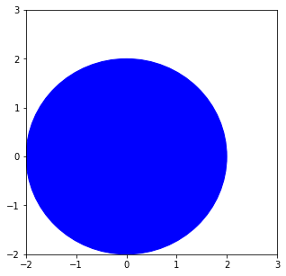

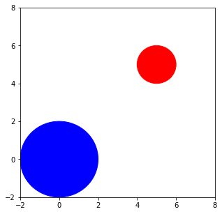

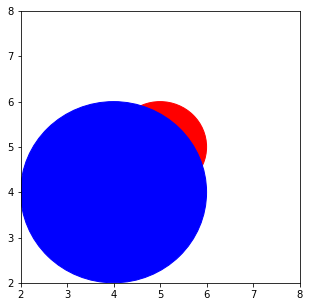

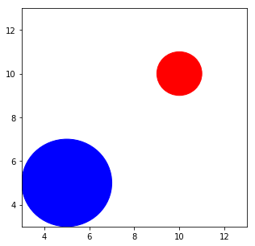

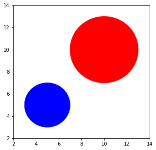

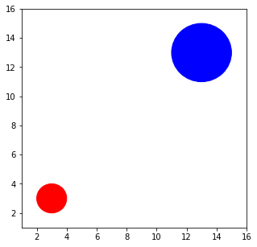

```python
for t in tests:
    args = [int(x.strip()) for x in t[0].split(' ')] + [int(y.strip()) for y in t[1].split(' ')]
    plot_circles(*args)
```

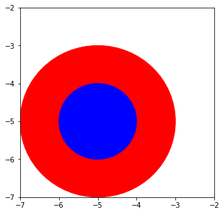

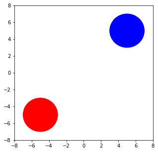

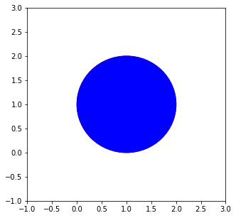

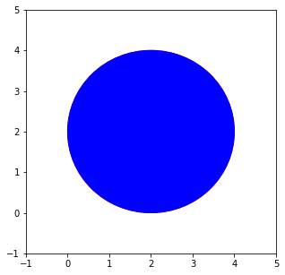

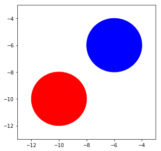

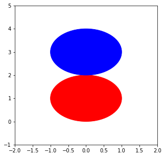

```python
for t in additional_tests:
    args = [int(x.strip()) for x in t[0].split(' ')] + [int(y.strip()) for y in t[1].split(' ')]
    plot_circles(*args)
```